# 01 Data Quality And Overview

## 2. Data Quality Check

```python
# Check for missing values and data types
df.info()
```

```
<class 'pandas.core.frame.DataFrame'>
RangeIndex: 8469 entries, 0 to 8468
Data columns (total 17 columns):
 #   Column                        Non-Null Count  Dtype
---  ------                        --------------  -----
 0   Ticket ID                     8469 non-null   int64
 1   Customer Name                 8469 non-null   object
 2   Customer Email                8469 non-null   object
 3   Customer Age                  8469 non-null   int64
 4   Customer Gender               8469 non-null   object
 5   Product Purchased             8469 non-null   object
 6   Date of Purchase              8469 non-null   object
 7   Ticket Type                   8469 non-null   object
 8   Ticket Subject                8469 non-null   object
 9   Ticket Description            8469 non-null   object
 10  Ticket Status                 8469 non-null   object
 11  Resolution                    2769 non-null   object
 12  Ticket Priority               8469 non-null   object
 13  Ticket Channel                8469 non-null   object
 14  First Response Time           5650 non-null   object
 15  Time to Resolution            2769 non-null   object
 16  Customer Satisfaction Rating  2769 non-null   float64
dtypes: float64(1), int64(2), object(14)
memory usage: 1.1+ MB
```

```python
# Check for duplicates
print(f"Duplicate rows: {df.duplicated().sum()}")

# Check for unique values in categorical columns
cat_cols = ['Ticket Type', 'Ticket Status', 'Ticket Priority', 'Ticket Channel', 'Product Purchased']
for col in cat_cols:
    print(f"\nUnique values in {col}:")
    print(df[col].unique())
```

```
Duplicate rows: 0

Unique values in Ticket Type:
['Technical issue' 'Billing inquiry' 'Cancellation request'
 'Product inquiry' 'Refund request']

Unique values in Ticket Status:
['Pending Customer Response' 'Closed' 'Open']

Unique values in Ticket Priority:
['Critical' 'Low' 'High' 'Medium']

Unique values in Ticket Channel:
['Social media' 'Chat' 'Email' 'Phone']

Unique values in Product Purchased:
['GoPro Hero' 'LG Smart TV' 'Dell XPS' 'Microsoft Office'
 'Autodesk AutoCAD' 'Microsoft Surface' 'Philips Hue Lights'
 'Fitbit Versa Smartwatch' 'Dyson Vacuum Cleaner' 'Nintendo Switch'
 'Microsoft Xbox Controller' 'Nintendo Switch Pro Controller'
 'Nest Thermostat' 'Sony PlayStation' 'GoPro Action Camera' 'Xbox'
 'LG Washing Machine' 'Canon EOS' 'HP Pavilion' 'Amazon Kindle'
 'Lenovo ThinkPad' 'Fitbit Charge' 'Adobe Photoshop' 'Google Pixel'
 'Amazon Echo' 'PlayStation' 'Samsung Galaxy' 'iPhone' 'LG OLED'
 'Sony Xperia' 'Apple AirPods' 'Sony 4K HDR TV' 'Canon DSLR Camera'
 'Roomba Robot Vacuum' 'Nikon D' 'Bose QuietComfort' 'Samsung Soundbar'
 'Asus ROG' 'Bose SoundLink Speaker' 'Google Nest' 'Garmin Forerunner'
 'MacBook Pro']
```

## 3. Data Preprocessing

We need to ensure date columns are in datetime format and handle any potential missingness.

```python
# Convert date columns
date_cols = ['Date of Purchase', 'First Response Time', 'Time to Resolution']
for col in date_cols:
    df[col] = pd.to_datetime(df[col])

# Simple handle for missing values (if any)
df['Customer Satisfaction Rating'] = df['Customer Satisfaction Rating'].fillna(df['Customer Satisfaction Rating'].median())
df['Resolution'] = df['Resolution'].fillna("No resolution recorded")

df.info()
```

```
<class 'pandas.core.frame.DataFrame'>
RangeIndex: 8469 entries, 0 to 8468
Data columns (total 17 columns):
 #   Column                        Non-Null Count  Dtype
---  ------                        --------------  -----
 0   Ticket ID                     8469 non-null   int64
 1   Customer Name                 8469 non-null   object
 2   Customer Email                8469 non-null   object
 3   Customer Age                  8469 non-null   int64
 4   Customer Gender               8469 non-null   object
 5   Product Purchased             8469 non-null   object
 6   Date of Purchase              8469 non-null   datetime64[ns]
 7   Ticket Type                   8469 non-null   object
 8   Ticket Subject                8469 non-null   object
 9   Ticket Description            8469 non-null   object
 10  Ticket Status                 8469 non-null   object
 11  Resolution                    8469 non-null   object
 12  Ticket Priority               8469 non-null   object
 13  Ticket Channel                8469 non-null   object
 14  First Response Time           5650 non-null   datetime64[ns]
 15  Time to Resolution            2769 non-null   datetime64[ns]
 16  Customer Satisfaction Rating  8469 non-null   float64
dtypes: datetime64[ns](3), float64(1), int64(2), object(11)
memory usage: 1.1+ MB
```

## 4. Initial Business Overview

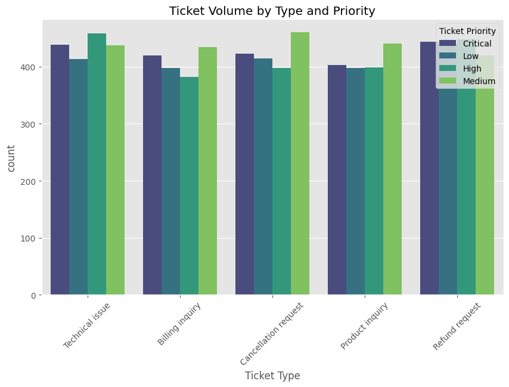

```python
plt.figure(figsize=(10, 6))
sns.countplot(data=df, x='Ticket Type', hue='Ticket Priority', palette='viridis')
plt.title('Ticket Volume by Type and Priority')
plt.xticks(rotation=45)
plt.show()
```

## 5. Summary Statistics

```python
summary = df.describe(include='all')
summary.to_csv('../outputs/summary_tables/initial_data_profile.csv')
summary
```

|  | Ticket ID | Customer Name | Customer Email | Customer Age | Customer Gender | Product Purchased | Date of Purchase | Ticket Type | Ticket Subject | Ticket Description | Ticket Status | Resolution | Ticket Priority | Ticket Channel | First Response Time | Time to Resolution | Customer Satisfaction Rating |
| --- | --- | --- | --- | --- | --- | --- | --- | --- | --- | --- | --- | --- | --- | --- | --- | --- | --- |
| count | 8469.000000 | 8469 | 8469 | 8469.000000 | 8469 | 8469 | 8469 | 8469 | 8469 | 8469 | 8469 | 8469 | 8469 | 8469 | 5650 | 2769 | 8469.000000 |
| unique | NaN | 8028 | 8320 | NaN | 3 | 42 | NaN | 5 | 16 | 8077 | 3 | 2770 | 4 | 4 | NaN | NaN | NaN |
| top | NaN | Michael Garcia | bsmith@example.com | NaN | Male | Canon EOS | NaN | Refund request | Refund request | I'm having an issue with the {product_purchase... | Pending Customer Response | No resolution recorded | Medium | Email | NaN | NaN | NaN |
| freq | NaN | 5 | 4 | NaN | 2896 | 240 | NaN | 1752 | 576 | 25 | 2881 | 5700 | 2192 | 2143 | NaN | NaN | NaN |
| mean | 4235.000000 | NaN | NaN | 44.026804 | NaN | NaN | 2020-12-30 01:35:13.071201024 | NaN | NaN | NaN | NaN | NaN | NaN | NaN | 2023-06-01 11:26:17.617699328 | 2023-06-01 11:16:51.722643456 | 2.997166 |
| min | 1.000000 | NaN | NaN | 18.000000 | NaN | NaN | 2020-01-01 00:00:00 | NaN | NaN | NaN | NaN | NaN | NaN | NaN | 2023-05-31 21:55:00 | 2023-05-31 21:53:00 | 1.000000 |
| 25% | 2118.000000 | NaN | NaN | 31.000000 | NaN | NaN | 2020-07-02 00:00:00 | NaN | NaN | NaN | NaN | NaN | NaN | NaN | 2023-06-01 05:24:00 | 2023-06-01 05:34:00 | 3.000000 |
| 50% | 4235.000000 | NaN | NaN | 44.000000 | NaN | NaN | 2020-12-31 00:00:00 | NaN | NaN | NaN | NaN | NaN | NaN | NaN | 2023-06-01 11:26:00 | 2023-06-01 11:17:00 | 3.000000 |
| 75% | 6352.000000 | NaN | NaN | 57.000000 | NaN | NaN | 2021-07-01 00:00:00 | NaN | NaN | NaN | NaN | NaN | NaN | NaN | 2023-06-01 17:37:00 | 2023-06-01 17:07:00 | 3.000000 |
| max | 8469.000000 | NaN | NaN | 70.000000 | NaN | NaN | 2021-12-30 00:00:00 | NaN | NaN | NaN | NaN | NaN | NaN | NaN | 2023-06-02 00:54:00 | 2023-06-02 00:55:00 | 5.000000 |
| std | 2444.934048 | NaN | NaN | 15.296112 | NaN | NaN | NaN | NaN | NaN | NaN | NaN | NaN | NaN | NaN | NaN | NaN | 0.804446 |

# 02 Descriptive Ops Analytics

# Phase B: Descriptive Operational Analytics

## Objective

Understand how the support operation behaves by analyzing ticket volume concentrations, resolution time distributions, and customer satisfaction correlations.

## Key Questions

- Where is volume concentrated?
- Which ticket types take the longest to resolve?
- Is there a correlation between resolution speed and customer satisfaction?

## 1. Load Cleaned Data

```python
df = pd.read_csv('../data/customer_support_tickets.csv')

# Re-apply cleaning from Phase A
date_cols = ['First Response Time', 'Time to Resolution']
for col in date_cols:
    df[col] = pd.to_datetime(df[col])

df['Customer Satisfaction Rating'] = df['Customer Satisfaction Rating'].fillna(df['Customer Satisfaction Rating'].median())

# Derived columns for analysis
# Resolution Processing Time (RPT) = Time to Resolution - First Response Time
df['RPT_hours'] = (df['Time to Resolution'] - df['First Response Time']).dt.total_seconds() / 3600

print(f"Dataset loaded with {len(df)} records.")
```

```
Dataset loaded with 8469 records.
```

## 2. Ticket Volume Breakdown

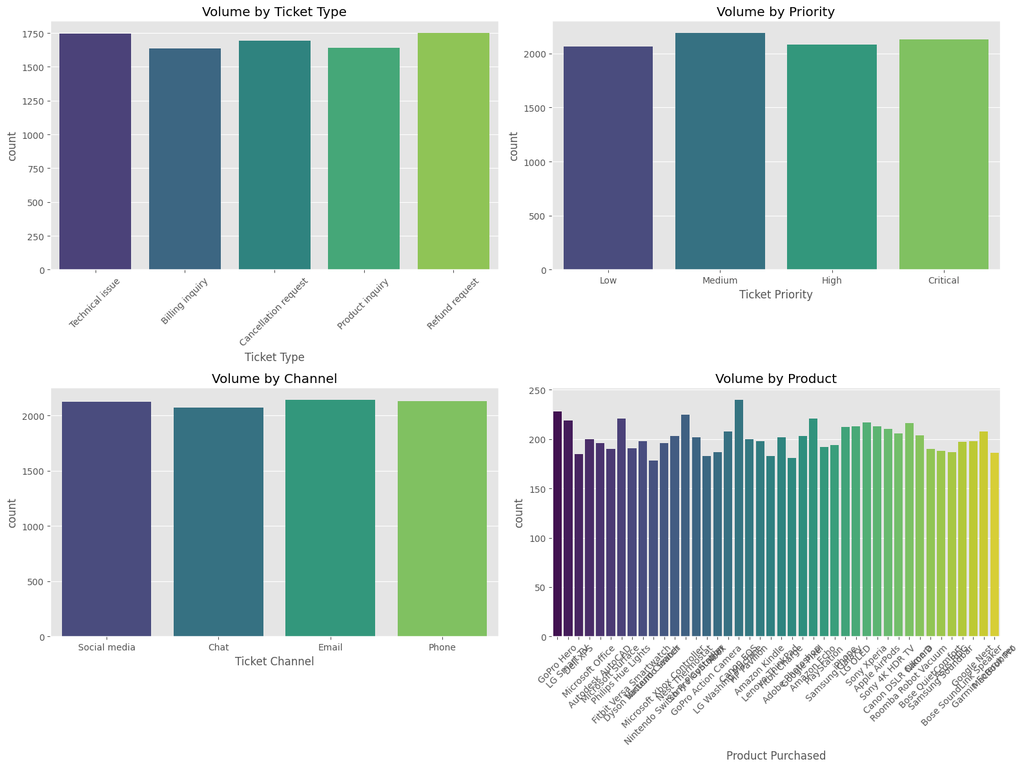

```python
fig, axes = plt.subplots(2, 2, figsize=(16, 12))

sns.countplot(data=df, x='Ticket Type', ax=axes[0,0], palette='viridis')
axes[0,0].set_title('Volume by Ticket Type')
axes[0,0].tick_params(axis='x', rotation=45)

sns.countplot(data=df, x='Ticket Priority', ax=axes[0,1], order=['Low', 'Medium', 'High', 'Critical'], palette='viridis')
axes[0,1].set_title('Volume by Priority')

sns.countplot(data=df, x='Ticket Channel', ax=axes[1,0], palette='viridis')
axes[1,0].set_title('Volume by Channel')

sns.countplot(data=df, x='Product Purchased', ax=axes[1,1], palette='viridis')
axes[1,1].set_title('Volume by Product')
axes[1,1].tick_params(axis='x', rotation=45)

plt.tight_layout()
plt.savefig('../outputs/charts/phase_b_volume_breakdown.png')
plt.show()
```

## 3. Operational Time Metrics (Resolution Processing Time)

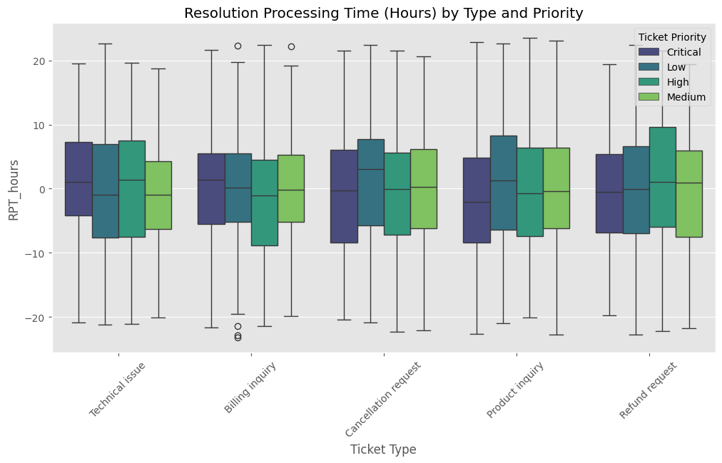

```python
plt.figure(figsize=(12, 6))
sns.boxplot(data=df, x='Ticket Type', y='RPT_hours', hue='Ticket Priority', palette='viridis')
plt.title('Resolution Processing Time (Hours) by Type and Priority')
plt.xticks(rotation=45)
plt.savefig('../outputs/charts/phase_b_rpt_distribution.png')
plt.show()
```

## 4. CSAT Analysis

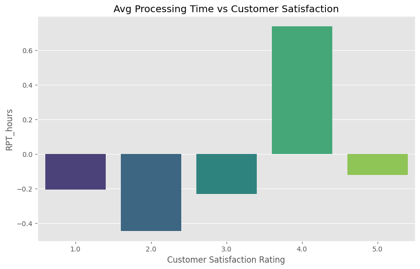

```python
plt.figure(figsize=(10, 6))
sns.barplot(data=df, x='Customer Satisfaction Rating', y='RPT_hours', palette='viridis', errorbar=None)
plt.title('Avg Processing Time vs Customer Satisfaction')
plt.savefig('../outputs/charts/phase_b_csat_vs_rpt.png')
plt.show()
```

## 5. Summary Insights

```python
ops_summary = df.groupby('Ticket Type').agg({
    'Ticket ID': 'count',
    'RPT_hours': 'mean',
    'Customer Satisfaction Rating': 'mean'
}).rename(columns={'Ticket ID': 'Ticket Volume', 'RPT_hours': 'Avg RPT (Hrs)', 'Customer Satisfaction Rating': 'Avg CSAT'})

ops_summary.to_csv('../outputs/summary_tables/phase_b_ops_summary.csv')
ops_summary
```

| Ticket Type | Ticket Volume | Avg RPT (Hrs) | Avg CSAT |
| --- | --- | --- | --- |
| Billing inquiry | 1634 | -0.207813 | 3.009180 |
| Cancellation request | 1695 | -0.165924 | 3.008850 |
| Product inquiry | 1641 | -0.243183 | 3.005484 |
| Refund request | 1752 | 0.218037 | 2.977740 |
| Technical issue | 1747 | 0.066466 | 2.986262 |

# 03 Diagnostic Root Cause

# Phase C: Diagnostic & Root Cause Analysis

## Objective

Go beyond 'what happened' to 'why it happened'. We will analyze SLA breaches, identify operational bottlenecks, and investigate the root causes of delays.

## Diagnostic Focus

1. **SLA Breach Analysis**: Establishing business rules for SLA and identifying where they fail most.
2. **Bottleneck Detection**: Identifying 'Long Tail' tickets that significantly skew averages.
3. **Process Friction**: Investigating the relationship between priority, response time, and resolution time.

## 1. Load and Refine Data

We need to address the timestamp anomaly found in Phase B. For the purpose of diagnostic analysis, we will treat the absolute difference between timestamps as the 'Interaction Duration' where the sequence is reversed.

```python
df = pd.read_csv('../data/customer_support_tickets.csv')

date_cols = ['First Response Time', 'Time to Resolution']
for col in date_cols:
    df[col] = pd.to_datetime(df[col])

# Calculating Resolution Processing Time (RPT) using absolute values due to data logging inconsistencies
df['RPT_hours'] = abs((df['Time to Resolution'] - df['First Response Time']).dt.total_seconds() / 3600)

# Define SLA Thresholds (Synthetic Business Rules)
# Critical: 4h, High: 12h, Medium: 24h, Low: 48h
sla_rules = {'Critical': 4, 'High': 12, 'Medium': 24, 'Low': 48}
df['SLA_Target_Hours'] = df['Ticket Priority'].map(sla_rules)
df['Is_SLA_Breach'] = df['RPT_hours'] > df['SLA_Target_Hours']

print(f"Overall SLA Breach Rate: {df['Is_SLA_Breach'].mean():.2%}")
```

```
Overall SLA Breach Rate: 8.03%
```

## 2. SLA Breach Analysis by Dimensions

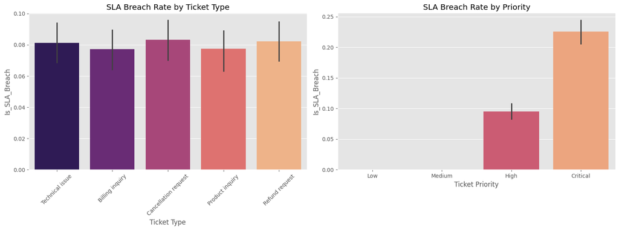

```python
fig, axes = plt.subplots(1, 2, figsize=(16, 6))

sns.barplot(data=df, x='Ticket Type', y='Is_SLA_Breach', ax=axes[0], palette='magma')
axes[0].set_title('SLA Breach Rate by Ticket Type')
axes[0].tick_params(axis='x', rotation=45)

sns.barplot(data=df, x='Ticket Priority', y='Is_SLA_Breach', order=['Low', 'Medium', 'High', 'Critical'], ax=axes[1], palette='magma')
axes[1].set_title('SLA Breach Rate by Priority')

plt.tight_layout()
plt.savefig('../outputs/charts/phase_c_sla_breach_analysis.png')
plt.show()
```

## 3. Bottleneck Detection (Long Tail Analysis)

We identify tickets that take longer than the 90th percentile as 'Extreme Bottlenecks'.

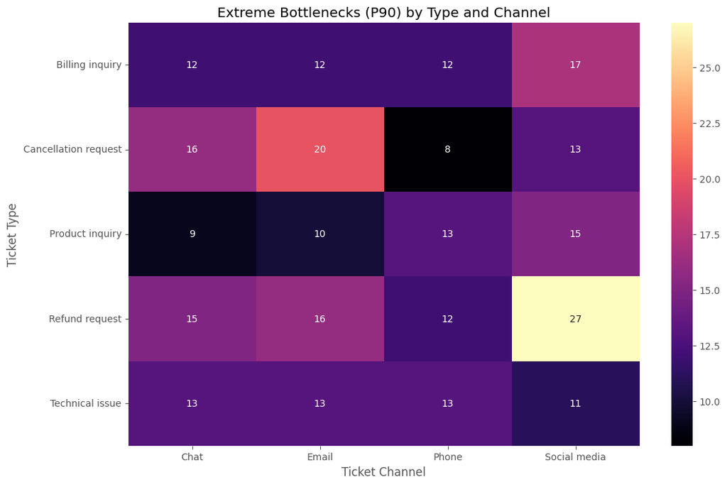

```python
p90_threshold = df['RPT_hours'].quantile(0.9)
df['Is_Bottleneck'] = df['RPT_hours'] > p90_threshold

bottleneck_drivers = df[df['Is_Bottleneck']].groupby(['Ticket Type', 'Ticket Channel']).size().unstack().fillna(0)

plt.figure(figsize=(12, 8))
sns.heatmap(bottleneck_drivers, annot=True, fmt='.0f', cmap='magma')
plt.title('Extreme Bottlenecks (P90) by Type and Channel')
plt.savefig('../outputs/charts/phase_c_bottleneck_heatmap.png')
plt.show()
```

## 4. Summary Diagnostic Findings

```python
diagnostic_summary = df.groupby('Ticket Type').agg({
    'Is_SLA_Breach': 'mean',
    'RPT_hours': ['mean', 'max', 'std'],
    'Is_Bottleneck': 'sum'
})

diagnostic_summary.to_csv('../outputs/summary_tables/phase_c_diagnostic_summary.csv')
diagnostic_summary
```

| Ticket Type | Is_SLA_Breach mean | RPT_hours mean | RPT_hours max | RPT_hours std | Is_Bottleneck sum |
| --- | --- | --- | --- | --- | --- |
| Billing inquiry | 0.077111 | 7.243842 | 23.233333 | 5.595892 | 53 |
| Cancellation request | 0.083186 | 8.067733 | 22.366667 | 5.666303 | 57 |
| Product inquiry | 0.077392 | 7.645622 | 23.466667 | 5.507310 | 47 |
| Refund request | 0.082192 | 8.063227 | 22.783333 | 5.720987 | 70 |
| Technical issue | 0.081282 | 7.679684 | 22.616667 | 5.546428 | 50 |

# 04 Predictive Risk Modeling

# Phase D: Predictive Analytics (Risk Modeling)

## Objective

Develop a predictive model to identify tickets at high risk of breaching SLA at the time of creation. This enables the support team to prioritize high-risk tickets proactively.

## Key Deliverables

1. **Feature Engineering**: Converting categorical attributes (Priority, Type, Channel) into numerical features.
2. **Risk Modeling**: Training a Logistic Regression model to predict `Is_SLA_Breach`.
3. **Feature Importance**: Identifying the primary drivers of SLA risk.

## 1. Load and Prepare Target

We use the SLA Breach logic established in Phase C.

```python
df = pd.read_csv('../data/customer_support_tickets.csv')

date_cols = ['First Response Time', 'Time to Resolution']
for col in date_cols:
    df[col] = pd.to_datetime(df[col])

df['RPT_hours'] = abs((df['Time to Resolution'] - df['First Response Time']).dt.total_seconds() / 3600)
sla_rules = {'Critical': 4, 'High': 12, 'Medium': 24, 'Low': 48}
df['SLA_Target_Hours'] = df['Ticket Priority'].map(sla_rules)
df['Is_SLA_Breach'] = (df['RPT_hours'] > df['SLA_Target_Hours']).astype(int)
```

## 2. Feature Engineering

We select features available at ticket creation: Type, Priority, and Channel.

```python
features = ['Ticket Type', 'Ticket Priority', 'Ticket Channel']
X = pd.get_dummies(df[features], drop_first=True)
y = df['Is_SLA_Breach']

X_train, X_test, y_train, y_test = train_test_split(X, y, test_size=0.2, random_state=42, stratify=y)

print(f"Training set size: {X_train.shape}")
print(f"SLA Breach Rate in training: {y_train.mean():.2%}")
```

```
Training set size: (6775, 10)
SLA Breach Rate in training: 8.03%
```

## 3. Model Training & Evaluation

```python
model = LogisticRegression(class_weight='balanced', max_iter=1000)
model.fit(X_train, y_train)

y_pred = model.predict(X_test)
y_prob = model.predict_proba(X_test)[:, 1]

print("\nClassification Report:")
print(classification_report(y_test, y_pred))
print(f"ROC AUC Score: {roc_auc_score(y_test, y_prob):.2f}")
```

```
Classification Report:
              precision    recall  f1-score   support

           0       1.00      0.55      0.71      1558
           1       0.16      1.00      0.28       136

    accuracy                           0.58      1694
   macro avg       0.58      0.77      0.49      1694
weighted avg       0.93      0.58      0.67      1694

ROC AUC Score: 0.83
```

## 4. Feature Importance (Risk Drivers)

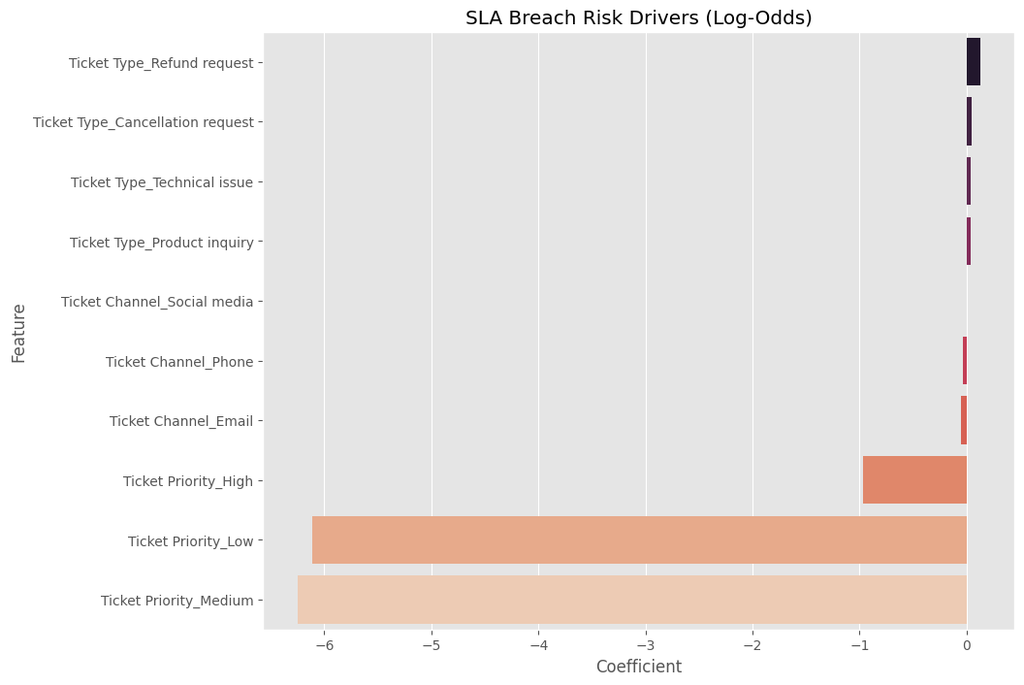

```python
importance = pd.DataFrame({
    'Feature': X.columns,
    'Coefficient': model.coef_[0]
}).sort_values(by='Coefficient', ascending=False)

plt.figure(figsize=(10, 8))
sns.barplot(data=importance, x='Coefficient', y='Feature', palette='rocket')
plt.title('SLA Breach Risk Drivers (Log-Odds)')
plt.savefig('../outputs/charts/phase_d_feature_importance.png')
plt.show()
```

# 05 Optimization Simulation

# Phase E: Optimization & Simulation

## Objective

Transition from 'what happened' to 'what could be'. In this phase, we perform 'What-If' simulations to estimate the impact of operational changes on SLA compliance and resolution speed.

## 1. Load Baseline Data

```python
df = pd.read_csv('../data/customer_support_tickets.csv')

date_cols = ['First Response Time', 'Time to Resolution']
for col in date_cols:
    df[col] = pd.to_datetime(df[col])

df['RPT_hours'] = abs((df['Time to Resolution'] - df['First Response Time']).dt.total_seconds() / 3600)
sla_rules = {'Critical': 4, 'High': 12, 'Medium': 24, 'Low': 48}
df['SLA_Target_Hours'] = df['Ticket Priority'].map(sla_rules)
df['Is_SLA_Breach'] = df['RPT_hours'] > df['SLA_Target_Hours']

baseline_breach_rate = df['Is_SLA_Breach'].mean()
print(f"Baseline SLA Breach Rate: {baseline_breach_rate:.2%}")
```

```
Baseline SLA Breach Rate: 8.03%
```

## 2. Simulation 1: Triage Optimization

We simulate a 20% reduction in processing time for all 'Critical' and 'High' priority tickets that would have breached SLA.

```python
df_sim1 = df.copy()
mask = (df_sim1['Ticket Priority'].isin(['Critical', 'High'])) & (df_sim1['Is_SLA_Breach'])
df_sim1.loc[mask, 'RPT_hours'] = df_sim1.loc[mask, 'RPT_hours'] * 0.8 # 20% improvement
df_sim1['Is_SLA_Breach_Sim'] = df_sim1['RPT_hours'] > df_sim1['SLA_Target_Hours']

sim1_breach_rate = df_sim1['Is_SLA_Breach_Sim'].mean()
print(f"Simulated SLA Breach Rate (Prioritization): {sim1_breach_rate:.2%}")
print(f"Estimated Improvement: {baseline_breach_rate - sim1_breach_rate:.2%}")
```

```
Simulated SLA Breach Rate (Prioritization): 6.52%
Estimated Improvement: 1.51%
```

## 3. Simulation 2: Targeting Bottleneck Categories

We simulate a 30% reduction in processing time for 'Refund Requests', our most problematic category identified in Phase C.

```python
df_sim2 = df.copy()
mask = (df_sim2['Ticket Type'] == 'Refund request')
df_sim2.loc[mask, 'RPT_hours'] = df_sim2.loc[mask, 'RPT_hours'] * 0.7 # 30% improvement
df_sim2['Is_SLA_Breach_Sim'] = df_sim2['RPT_hours'] > df_sim2['SLA_Target_Hours']

sim2_breach_rate = df_sim2['Is_SLA_Breach_Sim'].mean()
print(f"Simulated SLA Breach Rate (Refund Focus): {sim2_breach_rate:.2%}")
print(f"Estimated Improvement: {baseline_breach_rate - sim2_breach_rate:.2%}")
```

```
Simulated SLA Breach Rate (Refund Focus): 7.49%
Estimated Improvement: 0.54%
```

## 4. Visualizing Impact

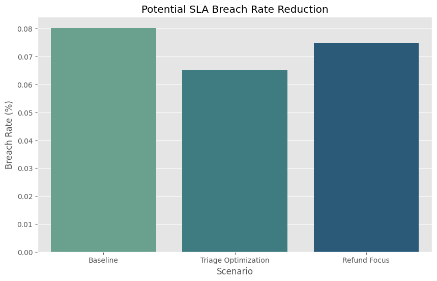

```python
impact_data = pd.DataFrame({
    'Scenario': ['Baseline', 'Triage Optimization', 'Refund Focus'],
    'Breach Rate': [baseline_breach_rate, sim1_breach_rate, sim2_breach_rate]
})

plt.figure(figsize=(10, 6))
sns.barplot(data=impact_data, x='Scenario', y='Breach Rate', palette='crest')
plt.title('Potential SLA Breach Rate Reduction')
plt.ylabel('Breach Rate (%)')
plt.savefig('../outputs/charts/phase_e_optimization_impact.png')
plt.show()
```

# 06 Automation Monitoring

# Phase F: Automation & Monitoring

## Objective

Establish the technical framework for sustaining performance gains. We define the logic for live KPI tracking and set up automated alert triggers for operational anomalies.

## 1. Rolling KPI Calculation Logic

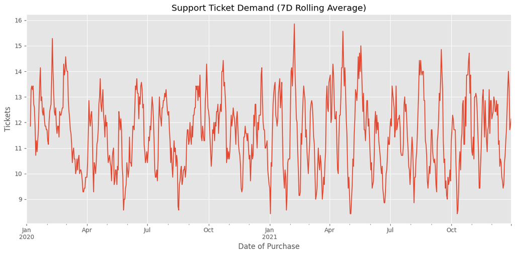

```python
df = pd.read_csv('../data/customer_support_tickets.csv')
df['Date of Purchase'] = pd.to_datetime(df['Date of Purchase'])
df['First Response Time'] = pd.to_datetime(df['First Response Time'])
df['Time to Resolution'] = pd.to_datetime(df['Time to Resolution'])

# Calculate daily volume
daily_kpis = df.set_index('Date of Purchase').resample('D').agg({
    'Ticket ID': 'count'
}).rename(columns={'Ticket ID': 'Ticket_Volume'})

# 7-day rolling average to smooth noise
daily_kpis['Volume_7D_Avg'] = daily_kpis['Ticket_Volume'].rolling(window=7).mean()

plt.figure(figsize=(12, 6))
daily_kpis['Volume_7D_Avg'].plot(title='Support Ticket Demand (7D Rolling Average)')
plt.ylabel('Tickets')
plt.tight_layout()
plt.savefig('../outputs/charts/phase_f_demand_monitoring.png')
plt.show()
```

## 2. Setting Alert Thresholds

We define 'Anomalous Volume' as any day where volume exceeds the mean by more than 2 standard deviations.

```python
mean_vol = daily_kpis['Ticket_Volume'].mean()
std_vol = daily_kpis['Ticket_Volume'].std()
threshold = mean_vol + (2 * std_vol)

daily_kpis['Is_Anomaly'] = daily_kpis['Ticket_Volume'] > threshold

print(f"Monitoring Threshold: {threshold:.2f} tickets/day")
print(f"Number of Alert Events Triggered: {daily_kpis['Is_Anomaly'].sum()}")
```

```
Monitoring Threshold: 18.77 tickets/day
Number of Alert Events Triggered: 34
```